# Law—You’re the Jury

# Foundational Concepts

[C]ertainly, in the law, there are many places where statistical data and inferences are used to help in making legal decisions. In this lecture, we’re going to look at two cases where you will be the jury.

```r
if (!caracas::has_sympy()) {
  caracas::install_sympy()
}
library(caracas)
library(sets)
library(tibble)
library(ggplot2)
library(dplyr)
```

```r
def_sym("X", "Y", "R")

cmStats <- modules::use("CmStats.R")$cmStats
```

We’ll look at two main examples of courtroom drama where we imagine ourselves on the jury. We’ll present the facts, and it will be up to us to determine what conclusions are appropriate to draw. We begin with a hit-and-run accident.

We will present the evidence; you determine the verdict.

• Mr. Jones witnessed a hit-and-run accident involving a cab.

• Mr. Jones stated that he thought the cab was blue.

• The jury has come to the conclusion that a guilty verdict hangs on whether or not Mr. Jones’s testimony implies that the probability that the cab was blue is over 50%.

• We did some experiments to determine how accurate Mr. Jones’s vision was. He was able to correctly identify the blue cabs as blue 80% of the time and the green cabs as green 80% of the time. The prosecutor summarized the situation by saying that Mr. Jones is 80% sure the cab was blue; therefore, the jury should convict.

Some additional information was presented:

• There are exactly 100 cabs in the city. • 90 are green cabs and 10 are blue.

```r
cabs_n = 100
blue_cabs = 10
green_cabs = 90
```

Let’s do the following thought experiment: Suppose instead of having one accident, all 100 cabs in the city simulated this accident. Each one did it once. How many times would Mr. Jones have testified that the cab was blue? Following the logic, we see that he would testify “blue” 26 times, but only 8 of those times would the cab actually be blue.

```r
cmStats$P(blue_cabs, cabs_n)
```

```
[1] 0.1
```

```r
cmStats$P(green_cabs, cabs_n)
```

```
[1] 0.9
```

Another case that demonstrates the same statistical issue about testing for rare events arises when considering random drug testing in a company. Suppose the company has 280,000 employees, of whom 500 employees actually use the illegal drugs that are the target of this policy. Suppose the drug test will correctly read positive for 95% of people who actually use those drugs; thus, 475 employees who use drugs would receive a positive test result.

```r
employees_n = 280000
under_substances = 500
tested_positive = 475
```

Now suppose that the test gives a false positive 1% of the time; of the 279,500 employees who do not use drugs, 1% will get a false- positive result. That is, the drug test will read positive for 2795 employees who do not, in fact, use drugs.

```r
employees_n - under_substances
```

```
[1] 279500
```

```r
cmStats$P(under_substances, employees_n)
```

```
[1] 0.001785714
```

```r
employees_n - tested_positive
```

```
[1] 279525
```

```r
cmStats$P(tested_positive, employees_n)
```

```
[1] 0.001696429
```

```r
employees_n - under_substances - tested_positive
```

```
[1] 279025
```

```r
cmStats$P(employees_n - under_substances - tested_positive, employees_n)
```

```
[1] 0.9965179
```

```r
tested_positive + (employees_n - tested_positive)
```

```
[1] 280000
```

```r
cmStats$P(tested_positive, tested_positive + (employees_n - tested_positive))
```

```
[1] 0.001696429
```

We now turn to gender discrimination. To determine discrimination by gender, race, religion, or age, it is natural to look at data about treatment of specific groups. Let’s consider a case of admissions to a program at a university. For the purposes of this example, let’s assume that 1000 men applied and 1000 women applied to the program and that all 2000 applicants had exactly the same qualifications. Here are the facts:

```r
mans <- 1000
womens <- 1000

applicants_n = mans + womens
```

```r
excellent_app_n = (mans - 800) + (womens - 200)

mediocre_app_n = (mans - 200) + (womens - 800)
```

```r
cmStats$P((mans - 800), excellent_app_n) + .20
```

```
[1] 0.4
```

```r
cmStats$P((womens - 200), excellent_app_n) + .25
```

```
[1] 1.05
```

```r
cmStats$P((mans - 200), mediocre_app_n) + 82.5
```

```
[1] 83.3
```

```r
(cmStats$P((womens - 800), mediocre_app_n) + 1.0)
```

```
[1] 1.2
```

Let’s look at a table that records the data:

```r
excellent_app_df <- tibble(
  applicants = c("women", "men", "total"),
  accept = c(40, 200, 240),
  reject = c(160, 600, 760),
  total = c(200, 800, 1000),
  accept_rates = c(.20, .25, .24)
    )
excellent_app_df
```

| applicants | accept | reject | total | accept_rates |
| --- | --- | --- | --- | --- |
| women | 40 | 160 | 200 | 0.20 |
| men | 200 | 600 | 800 | 0.25 |
| total | 240 | 760 | 1000 | 0.24 |

```r
mediocre_app_df <- tibble(
  applicants = c("women", "men", "total"),
  accept = c(660, 200, 860),
  reject = c(140, 0, 140),
  total = c(800, 200, 1000),
  accept_rates = c(.82, 1.0, .86)
    )
mediocre_app_df
```

| applicants | accept | reject | total | accept_rates |
| --- | --- | --- | --- | --- |
| women | 660 | 140 | 800 | 0.82 |
| men | 200 | 0 | 200 | 1.00 |
| total | 860 | 140 | 1000 | 0.86 |

## LINEAR REGRESSION MODELS AND ASSUMPTIONS

n regression, we look at the association between 2 or more quantitative variables. We’re going to begin to look for whether one variable causes or predicts changes in another variable. The response variable, which is the dependent variable, might measure an outcome of a study or experiment. The explanatory variable, which is the independent or predictor variable, explains or is related to changes in the response variable. We now have pairs of observations: $( 𝑥1, 𝑦1 ), ( 𝑥2, 𝑦2 ), …, ( 𝑥𝑛, 𝑦𝑛 )$. In linear regression, we’re looking for the association between 2 variables to be centered on a line. In essence, we’re looking for the effect that one variable has on another.

### LINEAR REGRESSION

Imagine that we are wheat farmers in Kansas. For the past 10 years, at the end of the season, we’ve recorded the total amount of rainfall and the average height of our wheat. We’d like to know if rainfall has any effect on our wheat yield.

We have 10 data points, each recording the amount of rainfall ( measured in inches ) and wheat growth ( in inches ). Here’s our data in R:

```r
rainfall = c(3.07,3.55,3.90,4.38,
4.79,5.30,5.42,5.99,6.45,6.77)
wheat = c(78,82,85,91,92,96,97,104,111,119)
summary(cbind(rainfall, wheat))
```

```
    rainfall         wheat
 Min.   :3.070   Min.   : 78.0
 1st Qu.:4.020   1st Qu.: 86.5
 Median :5.045   Median : 94.0
 Mean   :4.962   Mean   : 95.5
 3rd Qu.:5.848   3rd Qu.:102.2
 Max.   :6.770   Max.   :119.0
```

Notice that our scatterplot shows that there might be a linear relationship between rainfall and wheat yield.

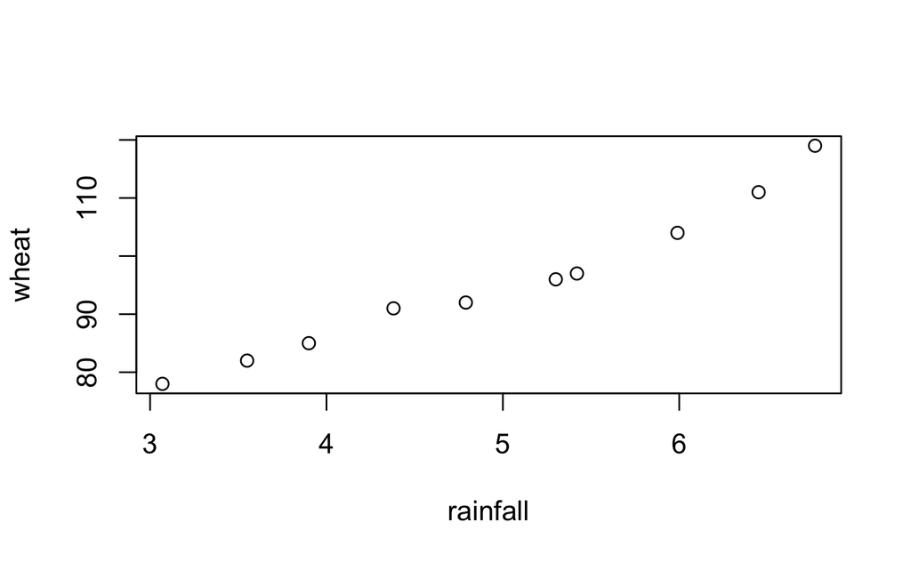

```r
plot(rainfall, wheat)
```

We can summarize the relationship between the 2 variables by fitting a regression line, which is a straight line that describes how a response variable 𝑦 changes as an explanatory variable 𝑥 changes and minimizes the squared difference ( also called residuals ) between each observation and the fitted line.

Our linear regression model, with unknown parameters, looks like this: $𝑦 = β0 + β1𝑥 + 𝜖$, where $β0$ is the 𝑦-intercept, $β1$ is the slope, and $𝜖$ is the error term.

R will conveniently fit a linear regression for us. We use the function “lm,” which stands for linear regression. After “lm” comes our response variable, “wheat,” followed by a tilde, which tells R that we want to model wheat on the explanatory variables that follow it. In this case, that’s rainfall.

```r
reg <-  lm(formula = wheat ~ rainfall)
reg
```

```
Call:
lm(formula = wheat ~ rainfall)

Coefficients:
(Intercept)     rainfall
      45.04        10.17
```

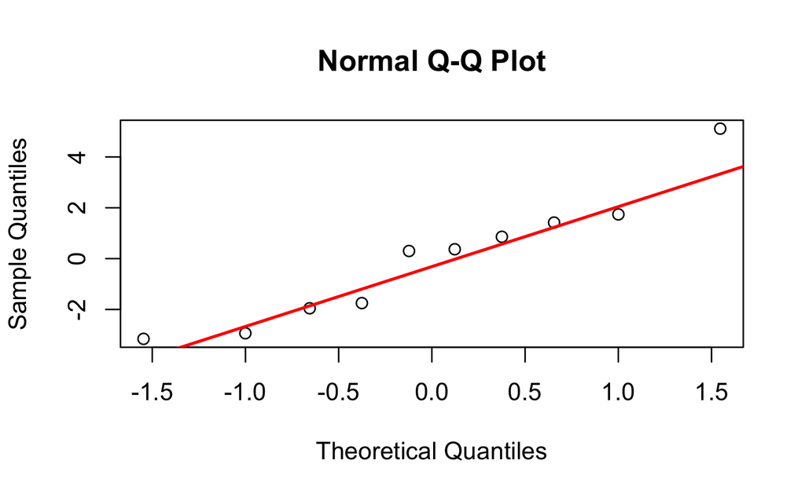

```r
qqnorm(reg$residuals)
qqline(reg$residuals, lwd=2, col="red")
```

### PREDICTIONS

We can use a regression line to predict the value of the response variable 𝑦 for a specific value of the explanatory variable 𝑥. This value is called a predicted value or fitted value.

Be careful about extrapolations. We can’t conclude that the regression line is an accurate model outside our sample data. In other words, just because our data supports a linear relationship between 𝑦 and 𝑥 doesn’t mean that that relationship holds for values outside the range of 𝑥. Predictions of 𝑦 for values of 𝑥 that are far away from the actual data range often aren’t accurate.

Let’s use our regression equation to actually predict the wheat yield.

```r
ŷ = reg$coefficients[1] + reg$coefficients[2] * X
ŷ
```

```
c: 10.1691192935516⋅X + 45.040830065397
```

With 5 inches of rain:

```r
ŷ = reg$coefficients[1] + reg$coefficients[2] * 5
ŷ
```

```
(Intercept)
   95.88643
```

With 100 inches of rain:

```r
ŷ = reg$coefficients[1] + reg$coefficients[2] * 100
ŷ
```

```
(Intercept)
   1061.953
```

### RESIDUALS

We need a way of understanding how well our regression line fits the data. The residuals help us do just that. A residual is the difference between an observed value $( Yi )$ and the value predicted by the regression line $( Ŷi ): ei = 𝑦i − ŷi$.

Some people get confused at this point, because it seems like the residuals, $e_i$, are the same as our errors, $𝜖_i$.

𝜖 measures the deviation of the observed value $( 𝑦 ) $from the unobservable, true regression line. ۧ ۧ The residuals, on the other hand, measure the difference between the observed value $( 𝑦i )$ and the estimated regression line $( ŷi )$.

A good plot, with some great residuals, looks like total randomness. There’s no pattern. And approximately the same number of points will be above and below the $e = 0$ line. A bad plot has some obvious pattern, such as a funnel shape or parabola. There might be more points above $0$ than below ( or vice versa ).

The following is a residual plot of the wheat data. There appears to be a pattern, but because there are so few data points, it’s best if we look at a quantile-quantile ( Q-Q ) plot—which confirms that our data, even though it’s small, satisfies the normality assumption.

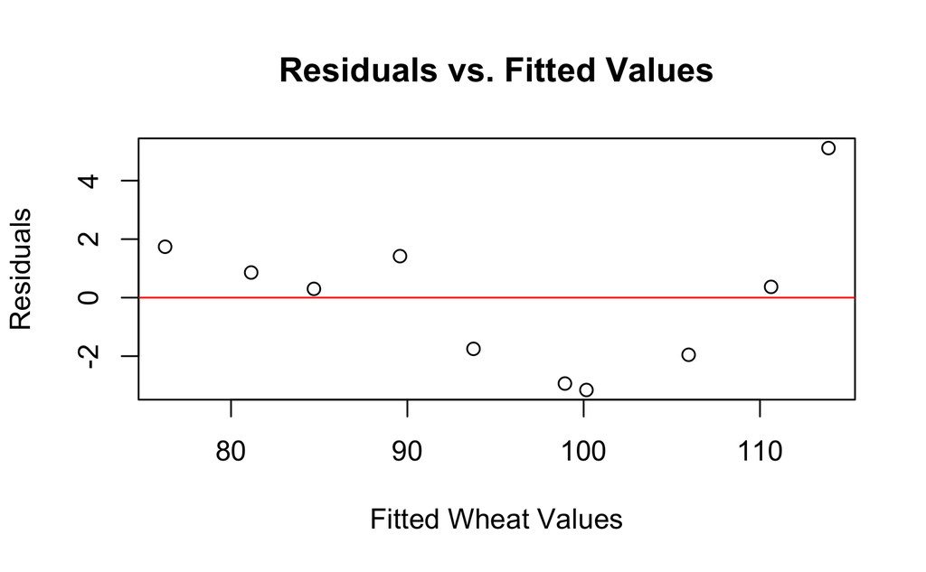

```r
rainfall = c(3.07,3.55,3.90,4.38,4.79,
5.30,5.42,5.99,6.45,6.77)
wheat = c(78,82,85,91,92,96,97,104,111,119)
wheat.lm = lm(wheat~rainfall)
plot(wheat.lm$fitted.values,wheat.lm$residuals,
main = "Residuals vs. Fitted Values",
xlab = "Fitted Wheat Values", ylab = "Residuals")
abline(h=0, col="red")
```

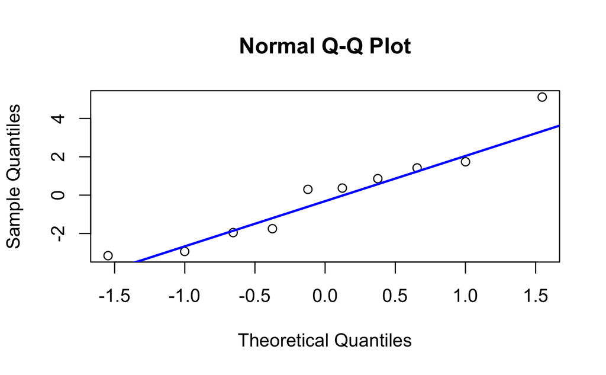

```r
qqnorm(residuals(lm(wheat~rainfall)))
qqline(residuals(lm(wheat~rainfall)), lwd=2, col="Blue")
```

### ASSESSING MODEL FIT

Now that we’ve fit a linear model to our data, we need to figure out how good it is. How well does it fit our data? Is the model strong enough that we could get good predictions from it? The following terminology will help us asses model fit.

The regression sum of squares ( SSR ) measures the variation in ŷi.

```r
SSR <-  sum_((cmStats$y_hat - X)^2, cmStats$i, 1, cmStats$n, doit = FALSE)
SSR
```

```
c:   n
    ___
    ╲
     ╲              2
     ╱   (-X + yₕₐₜ)
    ╱
    ‾‾‾
   i = 1
```

The error sum of squares ( SSE ) measures the residual variation in 𝑦 due to error. This is the sum of our residuals squared.

```r
SSE <-  sum_((Y - cmStats$y_hat)^2, cmStats$i, 1, cmStats$n, doit = FALSE)
SSE
```

```
c:   n
    ___
    ╲
     ╲             2
     ╱   (Y - yₕₐₜ)
    ╱
    ‾‾‾
   i = 1
```

```r
sum_(cmStats$e^2, cmStats$i, 1, cmStats$n, doit = FALSE)
```

```
c:   n
    ___
    ╲
     ╲    2
     ╱   e
    ╱
    ‾‾‾
   i = 1
```

The total sum of squares ( SST ) measures the total variation in 𝑦.

```r
SST <-  sum_((cmStats$y - Y)^2, cmStats$i, 1, cmStats$n, doit = FALSE)

SST
```

```
c:   n
    ___
    ╲
     ╲           2
     ╱   (-Y + y)
    ╱
    ‾‾‾
   i = 1
```

Note: $SST = SSR + SSE$. The coefficient of determination, R2, is the fraction of the variation in 𝑦 that can be explained by the linear regression of 𝑦 on 𝑥.

```r
SSR + SSE
```

```
c:   n                    n
    ___                  ___
    ╲                    ╲
     ╲              2     ╲             2
     ╱   (-X + yₕₐₜ)  +   ╱   (Y - yₕₐₜ)
    ╱                    ╱
    ‾‾‾                  ‾‾‾
   i = 1                i = 1
```

```r
R_sqr <- SSR/SST
R_sqr
```

```
c:   n
    ___
    ╲
     ╲              2
     ╱   (-X + yₕₐₜ)
    ╱
    ‾‾‾
   i = 1
   ──────────────────
      n
     ___
     ╲
      ╲           2
      ╱   (-Y + y)
     ╱
     ‾‾‾
    i = 1
```

```r
1 * (SSE/SST)
```

```
c:   n
    ___
    ╲
     ╲             2
     ╱   (Y - yₕₐₜ)
    ╱
    ‾‾‾
   i = 1
   ─────────────────
      n
     ___
     ╲
      ╲           2
      ╱   (-Y + y)
     ╱
     ‾‾‾
    i = 1
```

An R2 of 0 means that the 𝑦 cannot be predicted linearly from 𝑥. An R2 of 1 means that the 𝑦 can be predicted without error from 𝑥. An R2 between 0 and 1 indicates the extent to which 𝑦 is predictable by 𝑥. ( An R2 of 0.10 means that 10% of the variance in 𝑦 is predictable from 𝑥; an R2 of 0.80 means that 80% is predictable. )

We can’t forget to check our model assumptions.

To check for normality, we look at a normal Q-Q plot of the residuals.

To check for constant variability, we check the residual plot.

To check for independence, we examine the way in which subjects/ units were selected in the study or how the data was collected.

To check for linearity, we check a scatterplot or a residual plot.

It’s always important to check that the assumptions of the regression model have been met; otherwise, our results won’t be valid.